# Scientific visualizations with Quarto Markdown

Ina Krapp

## Scientific visualizations with Quarto Markdown:

**Objective:** In this workshop, we will explore a single dataset from three different visual perspectives. We will learn how to:

1. Visualize a network of connections using `networkD3`.
2. Plot geographic data on an interactive map with `leaflet`.
3. Create animated visualizations to show changes over time and simulate flight tracks with `gganimate`.

**Our Topic:** We will be exploring the US domestic air traffic network, focusing on flights departing from New York City’s three major airports in 2013.

## **Part 0: Setup**

First, let’s install the necessary packages and load our data. For this workshop, we will use a pre-prepared dataset derived from the `nycflights13` package. The dataset contains information on flights which departed from the three major airports in New York in 2013.

```r
# 1. Install the required packages
#install.packages(c("tidyverse", "networkD3", "leaflet", "gganimate"))

# 2. Load the libraries
library(tidyverse)
library(networkD3)
library(leaflet)
library(gganimate)
library(maps)

# Load data
flights_df <- read.csv("nyc_flights_2013.csv")
```

## Look at the dataset

```r
# Let's take a quick look at our data
glimpse(flights_df)
```

```
Rows: 329,174
Columns: 17
$ month        <int> 1, 1, 1, 1, 1, 1, 1, 1, 1, 1, 1, 1, 1, 1, 1, 1, 1, 1, 1, …
$ day          <int> 1, 1, 1, 1, 1, 1, 1, 1, 1, 1, 1, 1, 1, 1, 1, 1, 1, 1, 1, …
$ origin       <chr> "EWR", "LGA", "JFK", "LGA", "EWR", "EWR", "LGA", "JFK", "…
$ dest         <chr> "IAH", "IAH", "MIA", "ATL", "ORD", "FLL", "IAD", "MCO", "…
$ dest_name    <chr> "George Bush Intercontinental", "George Bush Intercontine…
$ origin_name  <chr> "Newark Liberty Intl", "La Guardia", "John F Kennedy Intl…
$ origin_lat   <dbl> 40.69250, 40.77725, 40.63975, 40.77725, 40.69250, 40.6925…
$ origin_lon   <dbl> -74.16867, -73.87261, -73.77893, -73.87261, -74.16867, -7…
$ dest_lat     <dbl> 29.98443, 29.98443, 25.79325, 33.63672, 41.97860, 26.0725…
$ dest_lon     <dbl> -95.34144, -95.34144, -80.29056, -84.42807, -87.90484, -8…
$ carrier      <chr> "UA", "UA", "AA", "DL", "UA", "B6", "EV", "B6", "AA", "B6…
$ dep_delay    <int> 2, 4, 2, -6, -4, -5, -3, -3, -2, -2, -2, -2, -2, -1, 0, -…
$ tzone_dest   <chr> "America/Chicago", "America/Chicago", "America/New_York",…
$ tzone_origin <chr> "America/New_York", "America/New_York", "America/New_York…
$ dep_time     <int> 517, 533, 542, 554, 554, 555, 557, 557, 558, 558, 558, 55…
$ arr_time     <int> 830, 850, 923, 812, 740, 913, 709, 838, 753, 849, 853, 92…
$ tailnum      <chr> "N14228", "N24211", "N619AA", "N668DN", "N39463", "N516JB…
```

## **Part 1: The Network of Flights (`networkD3`)**:

- Networks can be used to visualize relationships between people, places, organizations or other entities
- In flight data: A flight from an origin (e.g. John F. Kennedy Airport in New York) to a destination (e.g. Los Angeles International) can be modeled as a connection.
- We can model the entire system as a network where airports are *nodes* and routes are *links*. This will help us see the overall structure of the flight network out of NYC.

## Preparing data for a network

**Data Preparation:** `networkD3` requires data in a specific format:

1. A `nodes` data frame with information about each node (the airports).
2. A `links` data frame describing the connections, using numerical IDs that correspond to the rows in the `nodes` data frame.

## The Network of flights - nodes:

```r
# 1. Extract Origin Airport Data (origin_name and tzone_origin)
origin_airports <- flights_df %>%
  select(name_col = origin_name, time_col = tzone_origin) %>%
  # Remove duplicate rows
  distinct()

# 2. Extract Destination Airport Data (dest_name and tzone_dest)
destination_airports <- flights_df %>%
  select(name_col = dest_name, time_col = tzone_dest) %>%
  # Remove duplicate rows
  distinct()

# 3. Combine the two datasets into one master list
nodes <- bind_rows(
  origin_airports,
  destination_airports
)

# 4. Review the final dataframe structure
# View the first few rows to confirm
head(nodes)
```

## The Network of flights - links:

```r
# 1. Create the 'links' data frame
# We'll count the number of flights on each route to use as the link weight
links <- flights_df %>%
  group_by(origin_name, dest_name) %>%
  summarise(count = n(),.groups = 'drop')

# 2. Convert airport names (like 'John F Kennedy Intl') to zero-based numeric IDs
# We use match() to find the position of the airport code in our 'nodes' dataframe.
# networkD3 requires IDs to start from 0, so we subtract 1.
links$source_id <- match(links$origin_name, nodes$name) - 1
links$target_id <- match(links$dest_name, nodes$name) - 1
```

## The datasets for the network:

```r
# Let's see what we created
head(nodes)
```

```
                         name_col         time_col
1             Newark Liberty Intl America/New_York
2                      La Guardia America/New_York
3             John F Kennedy Intl America/New_York
4    George Bush Intercontinental  America/Chicago
5                      Miami Intl America/New_York
6 Hartsfield Jackson Atlanta Intl America/New_York
```

```r
head(links)
```

```
# A tibble: 6 × 5
  origin_name         dest_name                        count source_id target_id
  <chr>               <chr>                            <int>     <dbl>     <dbl>
1 John F Kennedy Intl Albuquerque International Sunpo…   254         2        95
2 John F Kennedy Intl Austin Bergstrom Intl             1471         2        49
3 John F Kennedy Intl Baltimore Washington Intl         1221         2        21
4 John F Kennedy Intl Birmingham Intl                      1         2        86
5 John F Kennedy Intl Bob Hope                           371         2        67
6 John F Kennedy Intl Buffalo Niagara Intl              3582         2        23
```

## Visualization of the network - code:

To create a network, the *links* and *nodes* datasets are used. Each node gets depicted with a name and a color. networkD3 networks can be saved as html.

```r
# Create the force-directed network plot
network = forceNetwork(
  Links = links,
  Nodes = nodes,
  Source = "source_id",
  Target = "target_id",
  Value = "count",        # Determines the thickness of the link
  NodeID = "name_col",        # The text to display when hovering over a node
  Group = "time_col",         # Color nodes by time zone
  opacity = 0.8,
  zoom = TRUE,            # Allow zooming
  fontSize = 12
)
# Save network:
saveNetwork(network = network, file = 'Network_flights.html')
```

## Visualization of the network:

- Hover over nodes to see their names.
- Drag nodes around to rearrange the layout.

```r
network
```

[interactive chart not shown]

## What the network shows:

**Takeaway:** We can immediately see the major hubs that connect to NYC.

- Some destinations have very few flights (thin lines), while others are major arteries of the network (thick lines).
- Since the data contains flights from New York, the three New York airports are at the center of the network.
- You can also see some airports are the destination of flights from just a single New York airport, while some are destinations of flights from two or all three airports.

## **Part 2: The Geographic View (`leaflet`)**

**Concept:** The network view is great for structure, but it lacks spatial context. Where are these airports actually located? A map is the perfect tool for this. We’ll plot all destination airports on an interactive map.

**Data Preparation:** We need a data frame of unique destinations with their coordinates and the number of flights they received.

```r
# Summarise the data to get one row per destination airport
destinations <- flights_df %>%
  group_by(dest, dest_name, dest_lat, dest_lon) %>%
  summarise(flight_count = n(), .groups = 'drop') %>%
  filter(!is.na(dest_lat)) # Ensure we have valid coordinates
```

## The dataset for the map:

```r
head(destinations)
```

```
# A tibble: 6 × 5
  dest  dest_name                         dest_lat dest_lon flight_count
  <chr> <chr>                                <dbl>    <dbl>        <int>
1 ABQ   Albuquerque International Sunport     35.0   -107.           254
2 ACK   Nantucket Mem                         41.3    -70.1          265
3 ALB   Albany Intl                           42.7    -73.8          439
4 ANC   Ted Stevens Anchorage Intl            61.2   -150.             8
5 ATL   Hartsfield Jackson Atlanta Intl       33.6    -84.4        17215
6 AUS   Austin Bergstrom Intl                 30.2    -97.7         2439
```

## Visualization of the map - code:

Let’s build our map. We’ll make the size of each circle proportional to the number of flights it received.

```r
# Create the interactive map
map = leaflet(data = destinations) %>%
  addProviderTiles("CartoDB.Positron") %>% # A clean, light-colored base map
  addCircleMarkers(
    lng = ~dest_lon,
    lat = ~dest_lat,
    radius = ~sqrt(flight_count / 100)+1, # Scale radius to make differences visible
    color = "#0072B2",
    stroke = FALSE,
    fillOpacity = 0.6,
    # Create a pop-up with information for each airport
    popup = ~paste(
      "<b>", dest_name, "</b><br>",
      "Airport Code: ", dest, "<br>",
      "Flights from NYC: ", flight_count
    )
  )
```

## Visualization of the map:

```r
map
```

[interactive chart not shown]

## Takeaway:

The map instantly reveals the geographic distribution of flights from NYC. We see a heavy concentration on the East Coast and to major cities like Chicago, Atlanta, and Los Angeles.

## **Part 3: The Temporal Dimension (`gganimate`)**:

**Concept:** We’ve seen the network structure and the geography, but when do things happen? Let’s explore how flight delays change throughout the year. An animation is the perfect way to see this pattern unfold.

```r
# Calculate average departure delay per month
monthly_delays <- flights_df %>%
  group_by(month) %>%
  summarise(avg_delay = mean(dep_delay, na.rm = TRUE))

# Let's create a "month_name" for better labels in our animation
monthly_delays$month_name <- month.name[monthly_delays$month]
monthly_delays$month_name <- factor(monthly_delays$month_name, levels = month.name)
```

## Taking a look at the data:

```r
head(monthly_delays)
```

```
# A tibble: 6 × 3
  month avg_delay month_name
  <int>     <dbl> <fct>
1     1      10.1 January
2     2      10.9 February
3     3      13.3 March
4     4      14.1 April
5     5      13.1 May
6     6      21.0 June
```

## Visualization of a line chart - code:

We’ll create a line chart that updates for each month of the year.

```r
# Ensure month_name is a factor in correct chronological order
# And we need a numeric version of month for transition_reveal to work smoothly
monthly_delays <- monthly_delays %>%
  mutate(month_num = as.numeric(month))

# 1. Create a static ggplot object
picture <- ggplot(monthly_delays, aes(x = month_num, y = avg_delay, group = 1)) +
  geom_line(size = 1.2, color = "darkred") +
  geom_point(size = 4, color = "darkred") +
  # We use scale_x_continuous to put the month names back on the numeric axis
  scale_x_continuous(breaks = 1:12, labels = month.name) +
  labs(
    title = 'Average Monthly Departure Delay from NYC in 2013',
    subtitle = 'Tracking up to: {month.name[as.integer(frame_along)]}',
    x = "Month",
    y = "Average Delay (minutes)"
  ) +
  theme_minimal() +
  theme(axis.text.x = element_text(angle = 45, hjust = 1))
```

## Visualization of a line chart:

```r
# Take a look at the graph:
picture
```

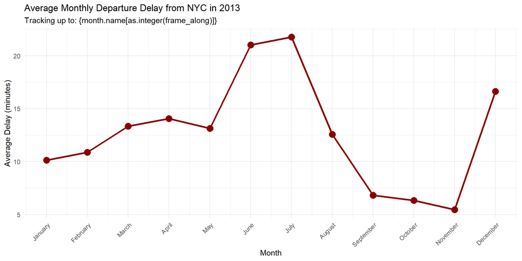

## Animation of a line chart - code:

One can transform a static graph like the one above into an animation using a ‘transition’ function. This function defines how the image above is turned into an animation. We use ‘transition_reveal’, which makes the data for months appear sequentially.

```r
# 2. Add the animation layer
# transition_reveal allows the line to "grow" along the x-axis
anim <- picture +                       # Alternative:
  transition_reveal(month_num) +   #transition_time(month_num)
  ease_aes('linear')
```

## Visualization of a line chart - Animation:

```r
anim
```

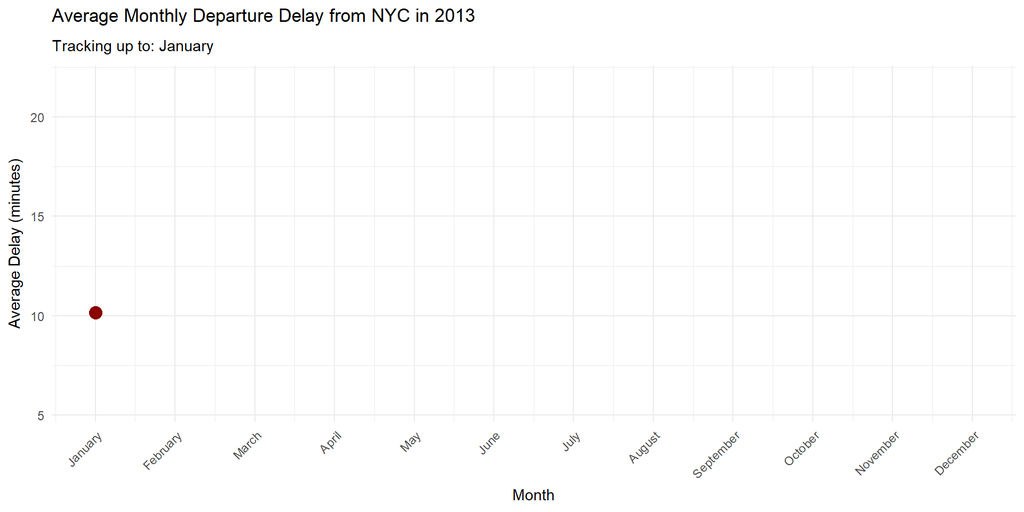

## Types of animations:

There are also other transition functions available, such as ‘transition_time’, which will make the animation go through time and always only show data for the current month. You can replace ‘transition_reveal’ by ‘transition_time’ in the previous code to see the difference.

They are intended for different data types and use different ways of tracking their status in the animation: ‘transition_reveal’ allows to include ‘frame_along’ into the animation, as seen above. ‘transition_time’ instead allows to track time through ‘frame_time’.

## Saving an animation:

- Animations are pictures which appear in close succession. One can define how many pictures, named ‘frames’, the final animation should include. The code below generates 100 frames, and then shows ten of them per second - therefore, the video will be 10 seconds long.
- One can increase width and height simultaneously to increase resolution. But then, the animation will also take longer to render.
- Using gifski_renderer, an animation can be saved as gif, but this code can not be dynamically run in a presentation, so it is commented out here.

## Saving an animation - code:

```r
# 3. Render the animation
# 'nframes': the number of frames generated.
# 'fps': 'frames per second'
#animate(anim, nframes = 100, fps = 10, width = 800, height = 400, renderer = gifski_renderer())

# 4. Save the animation
#anim_save("nyc_flight_delays_line.gif")
```

## Takeaway:

- The animation clearly shows a seasonal pattern! Delays are lowest in the fall months and peak during the summer (June, July) and holiday season (December), likely due to weather and increased traffic.
- Animations are computationally intensive, especially when rendered using a large number of frames and high resolution

## **Part 4: An animated map**

One can animate flights on a map by combining spatial and temporal data: In this part, we will simulate flights starting at New York airports flying to their destinations.

Working with dates can be involved, so for simplicity, we limit the flights to analyse to those who started and landed on the same day (those who weren’t in the air at midnight).

## Preparing data for animated flights:

```r
# 1. Prepare the data for movement
# We need to create a unique ID for each flight and convert times to numeric hours
flights_moving <- flights_df %>%
  filter(month == 1, day == 1) %>%
  mutate(
    flight_id = row_number(),
    # Convert HHMM to decimal hours (e.g., 6:30 -> 6.5)
    dep_time_num = (dep_time %/% 100) + (dep_time %% 100) / 60,
    arr_time_num = (arr_time %/% 100) + (arr_time %% 100) / 60
  ) %>%
  # Filter out flights that don't have arrival times or arrive 'the next day' for simplicity
  filter(!is.na(arr_time_num), arr_time_num > dep_time_num) %>%
  head(20) # We take the first 20 flights of the day for performance

# 2. CREATE THE "FLYING" STRUCTURE
# For every flight, we need a 'Start' row and an 'End' row
flight_steps <- bind_rows(
  flights_moving %>%
    select(flight_id, time = dep_time_num, lon = origin_lon, lat = origin_lat, carrier, tailnum),
  flights_moving %>%
    select(flight_id, time = arr_time_num, lon = dest_lon, lat = dest_lat, carrier, tailnum)
) %>%
  arrange(flight_id, time)

# 3. Get the map background
us_map <- map_data("state")
```

## A map of flights - code:

```r
# 4. Plot the "Flights"
picture <- ggplot() +
  # Background Map
  geom_polygon(data = us_map, aes(x = long, y = lat, group = group),
               fill = "#222222", color = "#444444") +
  # The Flight Paths (the "trails" the planes leave)
  geom_line(data = flight_steps,
            aes(x = lon, y = lat, group = flight_id, color = tailnum),
            alpha = 0.3) +
  # The Planes (the moving dots)
  geom_point(data = flight_steps,
             aes(x = lon, y = lat, color = tailnum),
             size = 3) +
  coord_fixed(1.3) +
  theme_void() +
  theme(panel.background = element_rect(fill = "black"),
        legend.position = "none",
        plot.title = element_text(color = "white", size = 18, hjust = 0.5),
        plot.subtitle = element_text(color = "white", size = 14, hjust = 0.5)) +
  labs(title = "A Day of Flights from NYC",
       subtitle = "Time: {round(frame_along, 1)}:00")
```

## A map of flights:

```r
# Depict map:
picture
```

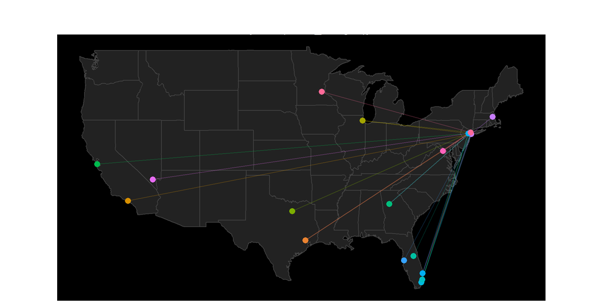

## A map of flights - animated:

```r
# 5. Animate using transition_reveal
# transition_reveal(time) tells gganimate to draw the line/point
# along the time axis based on the 'flight_id' group
anim <- picture +
  transition_reveal(time) +
  shadow_wake(wake_length = 0.1, alpha = 0.5) # Adds a "tail" to the plane
anim
```

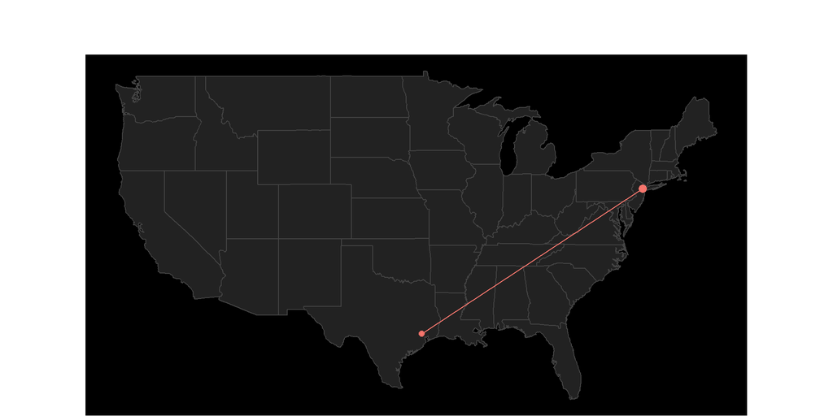

## A map of flights - code to save the animation:

```r
# 6. Render
#animate(anim, nframes = 150, fps = 15, width = 800, height = 500, renderer = gifski_renderer())

# 7. Save
#anim_save("nyc_flying_planes.gif")
```

Note that with more flights, the animation would quickly become crowded.

## Further literature:

A tutorial on creating graphics with ggplot2: https://datacenter.safe-frankfurt.de/documents/SAFE_webinars/03_ggplot/ggplot_tutorial.html

All types of network networkD3 can create with R code examples: https://christophergandrud.github.io/networkD3/

Another text on network analysis: https://bookdown.org/jdholster1/idsr/network-analysis.html

Mapping with leaflet or mapview in R: https://mapping-in-r-workshop.ryanpeek.org/04_vig_mapview_leaflet

All functions of gganimate: https://gganimate.com/reference/index.html